# Mapping Nitrogen Fixation Globally

Russell Dinnage and Anna Simonsen

06/08/2014

In this document, we will create a global map, with gridded values representing the proportion of occurring legume species that are nitrogen fixing. First we load the global occurrence data and then create a an overlaying grid, which we can use to aggregate the occurrence data over. Here, we use a mixture of spatial analysis functions from the `sp` package and data.frame manipulation functions of `dply` (to speed up calculations).

```r
library(GlobalNfix)
library(sp)
library(maps)
library(mapdata)
library(maptools)
library(rgdal)
library(ggplot2)
library(dplyr)
library(magrittr)
data(full_legume_data)
## convert to spatial object create grid of 5 degrees across globe (we can
## try other grid sizes as well)
grid <- GridTopology(c(-87.5, -177.5), c(5, 5), c(36, 72))
sp_grid <- coordinates(grid)
sp_grid <- sp_grid %>% data.frame %>% set_names(c("lat_centre", "long_centre")) %>%
    mutate(grid_id = seq_len(nrow(sp_grid)))
## assign points to grid
sp_grid_assign <- getGridIndex(cc = full_legume_data %>% select(decimalLatitude,
    decimalLongitude) %>% data.frame, grid = grid, all.inside = FALSE)
legume_grid <- full_legume_data %>% mutate(grid_id = sp_grid_assign) %>% left_join(sp_grid)
```

Now that we have that, we can use `dplyr` to calculate the proportion of nitrogen fixing and non-fixing legumes in each grid-cell. We will role up the above into a function as part of this package so we can easily recalculate for different grid-cell sizes. In the mean-time, let’s use `dplyr` to calculate the proportion of fixing legume species in each grid-cell.

```r
fix_prop_grid <- legume_grid %>% mutate(fixing = ifelse(Data_fixing == "Yes",
    1, 0)) %>% group_by(grid_id, Species) %>% summarise(fix_species = mean(fixing)) %>%
    group_by(grid_id) %>% summarise(fix_species = sum(fix_species), tot_species = n()) %>%
    mutate(prop_fix = fix_species/tot_species)
fix_prop_grid
```

```
Source: local data frame [882 x 4]

   grid_id fix_species tot_species prop_fix
1       10          38          39   0.9744
2       11          80          81   0.9877
3       13           3           4   0.7500
4       15           7           7   1.0000
5       16          18          23   0.7826
6       21          21          22   0.9545
7       29           4           4   1.0000
8       31           3           3   1.0000
9       32           2           2   1.0000
10      45          33          33   1.0000
..     ...         ...         ...      ...
```

Next, we generate polygons for each grid-cell and assign the nitrogen fixing proportion to the appropriate polygon. Then we can plot with `ggplot2`.

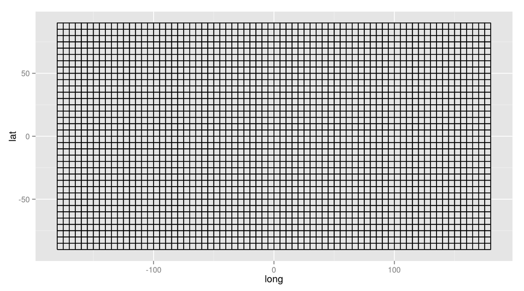

```r
## make polygons
grid_poly <- fortify(as.SpatialPolygons.GridTopology(grid)) %>% select(long = lat,
    lat = long, order, group) %>% mutate(grid_id = group)
levels(grid_poly$grid_id) <- levels(grid_poly$grid_id) %>% seq_along
grid_poly <- grid_poly %>% mutate(grid_id = grid_id %>% as.character %>% as.integer)
## check the grid
p <- ggplot(grid_poly, aes(x = long, y = lat, group = grid_id)) + geom_path()
p
```

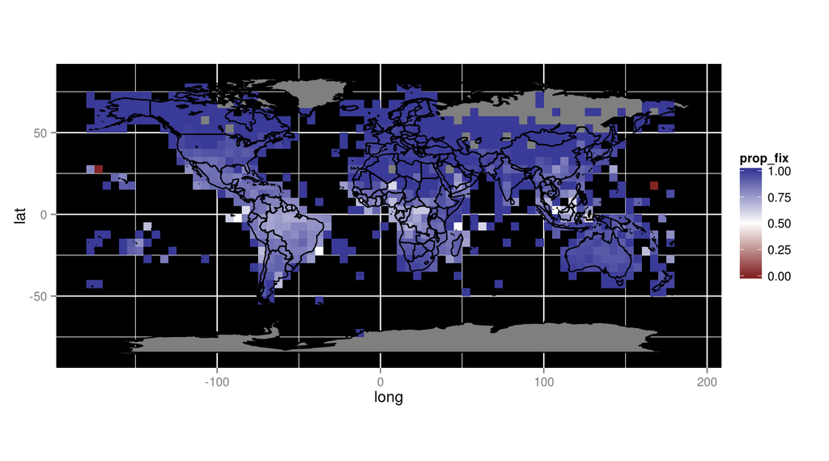

```r
fix_prop_grid <- grid_poly %>% inner_join(fix_prop_grid)
world_map <- map_data("world")
library(scales)
p <- ggplot(fix_prop_grid, aes(x = long, y = lat, group = grid_id)) + geom_polygon(data = world_map,
    aes(x = long, y = lat, group = group), size = 0, fill = "grey50") + geom_polygon(aes(fill = prop_fix)) +
    geom_path(data = world_map, aes(x = long, y = lat, group = group), colour = "black") +
    theme(panel.background = element_rect(fill = "black")) + scale_fill_gradient2(low = muted("red"),
    mid = "white", high = muted("blue"), midpoint = 0.5, space = "rgb", na.value = "grey50",
    guide = "colourbar") + coord_equal()
p
```

For the above figure it would be good to mask out the areas in the ocean. And find a better projection too. We will use the ‘Robinson’ projection. Also, we will exclude any grid-cells with fewer than 5 data points as unreliable.

```r
set_ll_warn(TRUE)
```

```
[1] TRUE
```

```r
robin_grid <- SpatialPoints(fix_prop_grid %>% select(long, lat), CRS("+proj=longlat +ellps=WGS84")) %>%
    spTransform(CRS("+proj=robin +ellps=WGS84")) %>% coordinates
fix_prop_grid <- fix_prop_grid %>% mutate(long_robin = robin_grid[, 1], lat_robin = robin_grid[,
    2], rel_fix = ifelse(tot_species < 5, NA, prop_fix))
## load Natural Earth map data
world_map <- readOGR(dsn = "/home/annarussell/GeoData/Natural_Earth/50m", layer = "ne_50m_land")
```

```
with 1420 features and 2 fields
Feature type: wkbPolygon with 2 dimensions
```

```r
ocean_poly <- readOGR(dsn = "/home/annarussell/GeoData/Natural_Earth/50m", layer = "ne_50m_ocean")
```

```
with 1 features and 2 fields
Feature type: wkbMultiPolygon with 2 dimensions
```

```r
grats <- readOGR(dsn = "/home/annarussell/GeoData/Natural_Earth/50m", layer = "ne_50m_graticules_20")
```

```
with 27 features and 6 fields
Feature type: wkbLineString with 2 dimensions
```

```r
wmap_df_robin <- spTransform(world_map, CRS("+proj=robin")) %>% fortify
ocean_df_robin <- spTransform(ocean_poly, CRS("+proj=robin")) %>% fortify
grats_df_robin <- spTransform(grats, CRS("+proj=robin")) %>% fortify

## convert grid-cells back to SpatialPolygons
grid_polys <- fix_prop_grid %>% group_by(grid_id) %>% do(poly = Polygon(as.matrix(select(.,
    long, lat)))) %>% do(polys = Polygons(list(.$poly), .$grid_id))

sp_grid_polys <- SpatialPolygons(grid_polys$poly, proj4string = CRS("+proj=longlat"))

## calculate intersection
library(rgeos)
library(tidyr)
sp_intersect <- gIntersection(sp_grid_polys, world_map, byid = TRUE)
new_grid <- spTransform(sp_intersect, CRS("+proj=robin")) %>% fortify %>% separate(id,
    c("grid_id", "poly2"), " ", convert = TRUE) %>% left_join(fix_prop_grid %>%
    select(grid_id, rel_fix))
```

Now to plot the new map!

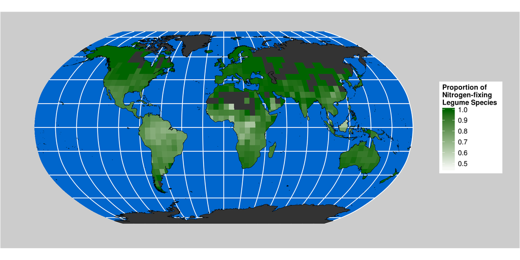

```r
theme_opts <- list(theme(panel.grid.minor = element_blank(), panel.grid.major = element_blank(),
    panel.background = element_blank(), plot.background = element_rect(fill = "grey80"),
    panel.border = element_blank(), axis.line = element_blank(), axis.text.x = element_blank(),
    axis.text.y = element_blank(), axis.ticks = element_blank(), axis.title.x = element_blank(),
    axis.title.y = element_blank(), plot.title = element_text(size = 22)))

p <- ggplot(new_grid, aes(x = long, y = lat, group = group)) + geom_polygon(data = ocean_df_robin,
    aes(long, lat, group = group), fill = "#0066CC") + geom_path(data = grats_df_robin,
    aes(long, lat, group = group), colour = "white") + geom_polygon(data = wmap_df_robin,
    aes(x = long, y = lat, group = group), size = 0, fill = "grey20") + geom_polygon(aes(fill = rel_fix)) +
    geom_path(data = wmap_df_robin, aes(x = long, y = lat, group = group), colour = "black",
        size = 0.2) + theme_opts + scale_fill_gradient(low = "white", high = "darkgreen",
    na.value = NA, name = "Proportion of\nNitrogen-fixing\nLegume Species") +
    coord_equal()
p
```

Let’s make a large high-res map:

```r
pdf(file = "Maps/NfixMap_Global.pdf", width = 30, height = 20)
p
dev.off()
```